# **Problem Statement**

# **Model Building**

**Given the scope of the project is to have a model to predict "Sales Forecast", and considering non linear relationship between target and predictive variables. To obtain better performance and accuracy I am selecting below two models for model development from the given models.**

- **Random Forest**
- **XGBoost**

## Define functions for Model Evaluation

```python
# function to compute adjusted R-squared
def adj_r2_score(predictors, targets, predictions):
    r2 = r2_score(targets, predictions)
    n = predictors.shape[0]
    k = predictors.shape[1]
    return 1 - ((1 - r2) * (n - 1) / (n - k - 1))


# function to compute different metrics to check performance of a regression model
def model_performance_regression(model, model_name, predictors, target):
    """
    Function to compute different metrics to check regression model performance

    model: regressor
    predictors: independent variables
    target: dependent variable
    """

    # predicting using the independent variables
    pred = model.predict(predictors)

    r2 = r2_score(target, pred)  # to compute R-squared
    adjr2 = adj_r2_score(predictors, target, pred)  # to compute adjusted R-squared
    rmse = np.sqrt(mean_squared_error(target, pred))  # to compute RMSE
    mae = mean_absolute_error(target, pred)  # to compute MAE
    mape = mean_absolute_percentage_error(target, pred)  # to compute MAPE

    # creating a dataframe of metrics
    df_perf = pd.DataFrame(
        {
            "Model Name:" : model_name,
            "RMSE": rmse,
            "MAE": mae,
            "R-squared": r2,
            "Adj. R-squared": adjr2,
            "MAPE": mape,
        },
        index=[0],
    )

    return df_perf
```

The ML models to be built can be any two out of the following:

1. Decision Tree
2. Bagging
3. Random Forest
4. AdaBoost
5. Gradient Boosting
6. XGBoost

## Random Forest

```python
rf_model1 = RandomForestRegressor(random_state=42)
```

```python
rf_m1_pipeline = Pipeline(
    steps = [
        ('preprocessor', preprocessor),
        ('rf_model1', rf_model1)
    ]
)
```

```python
rf_m1_pipeline.fit(X_train, y_train)
```

```
Pipeline(steps=[('preprocessor',
                 ColumnTransformer(remainder='passthrough',
                                   transformers=[('drop_cols', 'drop',
                                                  ['Product_Id', 'Store_Id']),
                                                 ('log_transf_cols',
                                                  FunctionTransformer(func=<ufunc 'log1p'>),
                                                  ['Product_Allocated_Area']),
                                                 ('onehotenco_cols',
                                                  OneHotEncoder(handle_unknown='ignore'),
                                                  ['Product_Sugar_Content',
                                                   'Product_Type', 'Store_Size',
                                                   'Store_Location_City_Type',
                                                   'Store_Type']),
                                                 ('passthrough_cols',
                                                  'passthrough',
                                                  ['Product_Weight',
                                                   'Product_MRP',
                                                   'Store_Establishment_Year'])])),
                ('rf_model1', RandomForestRegressor(random_state=42))])
```

```python
X_train_mdl_perf_metrx_df = model_performance_regression(rf_m1_pipeline, 'RF_default', X_train, y_train)
X_train_mdl_perf_metrx_df
```

|  | Model Name: | RMSE | MAE | R-squared | Adj. R-squared | MAPE |
| --- | --- | --- | --- | --- | --- | --- |
| 0 | RF_default | 0.038772 | 0.01372 | 0.988665 | 0.988647 | 0.001765 |

```python
X_test_mdl_perf_metrx_df = model_performance_regression(rf_m1_pipeline, 'RF_default', X_test, y_test)
X_test_mdl_perf_metrx_df
```

|  | Model Name: | RMSE | MAE | R-squared | Adj. R-squared | MAPE |
| --- | --- | --- | --- | --- | --- | --- |
| 0 | RF_default | 0.099796 | 0.033304 | 0.92314 | 0.922162 | 0.004289 |

```python
X_train_mdl_perf_metrx_df[['RMSE',	'MAE', 'R-squared',	'Adj. R-squared',	'MAPE']].subtract(X_test_mdl_perf_metrx_df[['RMSE',	'MAE', 'R-squared',	'Adj. R-squared',	'MAPE']])
```

|  | RMSE | MAE | R-squared | Adj. R-squared | MAPE |
| --- | --- | --- | --- | --- | --- |
| 0 | -0.061024 | -0.019584 | 0.065526 | 0.066485 | -0.002524 |

```python
rf_model1.get_params()
```

```
{'bootstrap': True,
 'ccp_alpha': 0.0,
 'criterion': 'squared_error',
 'max_depth': None,
 'max_features': 1.0,
 'max_leaf_nodes': None,
 'max_samples': None,
 'min_impurity_decrease': 0.0,
 'min_samples_leaf': 1,
 'min_samples_split': 2,
 'min_weight_fraction_leaf': 0.0,
 'monotonic_cst': None,
 'n_estimators': 100,
 'n_jobs': None,
 'oob_score': False,
 'random_state': 42,
 'verbose': 0,
 'warm_start': False}
```

```python
Pipeline.get_params(rf_m1_pipeline)
```

[output not shown]

[output cut: 40 more lines]

```
 'rf_model1__max_depth': None,
 'rf_model1__max_features': 1.0,
 'rf_model1__max_leaf_nodes': None,
 'rf_model1__max_samples': None,
 'rf_model1__min_impurity_decrease': 0.0,
 'rf_model1__min_samples_leaf': 1,
 'rf_model1__min_samples_split': 2,
 'rf_model1__min_weight_fraction_leaf': 0.0,
 'rf_model1__monotonic_cst': None,
 'rf_model1__n_estimators': 100,
 'rf_model1__n_jobs': None,
 'rf_model1__oob_score': False,
 'rf_model1__random_state': 42,
 'rf_model1__verbose': 0,
 'rf_model1__warm_start': False}
```

- RMSE and MAE are lower on training set compared to test set.Indicating model has smaller errors on training set than test set.
- R-Squared & Adj R-Squared: Though both training and tests sets are having both at range of 0.9 however, there is 0.06 drop from training to test set.
- MAPE is significantly low on training set indicating almost perfect percentage, however there is higher on test.

**Significant difference in performance metrics on training and test set suggest model is overfitting on training data.**

## XGBoost

```python
XGB_model1 = XGBRegressor(random_state=42)
```

```python
xgb_m1_pipeline = Pipeline(
    steps = [
        ('preprocessor', preprocessor),
        ('XGB_model1', XGB_model1)
    ]
)
```

```python
xgb_m1_pipeline.fit(X_train, y_train)
```

```
Pipeline(steps=[('preprocessor',
                 ColumnTransformer(remainder='passthrough',
                                   transformers=[('drop_cols', 'drop',
                                                  ['Product_Id', 'Store_Id']),
                                                 ('log_transf_cols',
                                                  FunctionTransformer(func=<ufunc 'log1p'>),
                                                  ['Product_Allocated_Area']),
                                                 ('onehotenco_cols',
                                                  OneHotEncoder(handle_unknown='ignore'),
                                                  ['Product_Sugar_Content',
                                                   'Product_Type', 'Store_Size',
                                                   'Store_Location_...
                              feature_types=None, gamma=None, grow_policy=None,
                              importance_type=None,
                              interaction_constraints=None, learning_rate=None,
                              max_bin=None, max_cat_threshold=None,
                              max_cat_to_onehot=None, max_delta_step=None,
                              max_depth=None, max_leaves=None,
                              min_child_weight=None, missing=nan,
                              monotone_constraints=None, multi_strategy=None,
                              n_estimators=None, n_jobs=None,
                              num_parallel_tree=None, random_state=42, ...))])
```

```python
X_train_mdl_perf_metrx_df = pd.concat([X_train_mdl_perf_metrx_df, model_performance_regression(xgb_m1_pipeline, 'XGB_default', X_train, y_train)], ignore_index=True)
X_train_mdl_perf_metrx_df
```

|  | Model Name: | RMSE | MAE | R-squared | Adj. R-squared | MAPE |
| --- | --- | --- | --- | --- | --- | --- |
| 0 | RF_default | 0.038772 | 0.013720 | 0.988665 | 0.988647 | 0.001765 |
| 1 | XGB_default | 0.042703 | 0.020132 | 0.986250 | 0.986229 | 0.002519 |

```python
X_test_mdl_perf_metrx_df = pd.concat([X_test_mdl_perf_metrx_df, model_performance_regression(xgb_m1_pipeline, 'XGB_default', X_test, y_test)], ignore_index=True)
X_test_mdl_perf_metrx_df
```

|  | Model Name: | RMSE | MAE | R-squared | Adj. R-squared | MAPE |
| --- | --- | --- | --- | --- | --- | --- |
| 0 | RF_default | 0.099796 | 0.033304 | 0.923140 | 0.922162 | 0.004289 |
| 1 | XGB_default | 0.101287 | 0.039534 | 0.920827 | 0.919820 | 0.005032 |

```python
X_train_mdl_perf_metrx_df[['RMSE',	'MAE', 'R-squared',	'Adj. R-squared',	'MAPE']].subtract(X_test_mdl_perf_metrx_df[['RMSE',	'MAE', 'R-squared',	'Adj. R-squared',	'MAPE']])
```

|  | RMSE | MAE | R-squared | Adj. R-squared | MAPE |
| --- | --- | --- | --- | --- | --- |
| 0 | -0.061024 | -0.019584 | 0.065526 | 0.066485 | -0.002524 |
| 1 | -0.058584 | -0.019402 | 0.065423 | 0.066409 | -0.002513 |

```python
XGB_model1.get_params()
```

```
{'objective': 'reg:squarederror',
 'base_score': None,
 'booster': None,
 'callbacks': None,
 'colsample_bylevel': None,
 'colsample_bynode': None,
 'colsample_bytree': None,
 'device': None,
 'early_stopping_rounds': None,
 'enable_categorical': False,
 'eval_metric': None,
 'feature_types': None,
 'gamma': None,
 'grow_policy': None,
 'importance_type': None,
 'interaction_constraints': None,
 'learning_rate': None,
 'max_bin': None,
 'max_cat_threshold': None,
 'max_cat_to_onehot': None,
 'max_delta_step': None,
 'max_depth': None,
 'max_leaves': None,
 'min_child_weight': None,
 'missing': nan,
 'monotone_constraints': None,
 'multi_strategy': None,
 'n_estimators': None,
 'n_jobs': None,
 'num_parallel_tree': None,
 'random_state': 42,
 'reg_alpha': None,
 'reg_lambda': None,
 'sampling_method': None,
 'scale_pos_weight': None,
 'subsample': None,
 'tree_method': None,
 'validate_parameters': None,
 'verbosity': None}
```

```python
Pipeline.get_params(xgb_m1_pipeline)
```

[output not shown]

[output cut: 82 more lines]

```
 'XGB_model1__missing': nan,
 'XGB_model1__monotone_constraints': None,
 'XGB_model1__multi_strategy': None,
 'XGB_model1__n_estimators': None,
 'XGB_model1__n_jobs': None,
 'XGB_model1__num_parallel_tree': None,
 'XGB_model1__random_state': 42,
 'XGB_model1__reg_alpha': None,
 'XGB_model1__reg_lambda': None,
 'XGB_model1__sampling_method': None,
 'XGB_model1__scale_pos_weight': None,
 'XGB_model1__subsample': None,
 'XGB_model1__tree_method': None,
 'XGB_model1__validate_parameters': None,
 'XGB_model1__verbosity': None}
```

**Similar to the explanation provided on random forest model scores analysis, based on above difference between XGBoost training and test scores, we can conclude, both "Random Forest" and "XGBoost" default models are overfitting on training data.**

# **Model Performance Improvement - Hyperparameter Tuning**

## Randform Forest

```python
rf_tuned_model1 = RandomForestRegressor(random_state = 42)
```

```python
rf_tuned_m1_pipeline = Pipeline(
    steps = [
        ('preprocessor', preprocessor),
        ('rf_tuned_model1', rf_tuned_model1)
    ]
)
```

```python
param_grid = {
    'rf_tuned_model1__n_estimators': [50, 100, 150, 200, 300],
    'rf_tuned_model1__max_depth': [5, 10, 15, 20, None],
    'rf_tuned_model1__min_samples_split': [2, 5, 10],
    'rf_tuned_model1__min_samples_leaf': [1, 2, 4],
    'rf_tuned_model1__max_features': ['sqrt', 'log2', 0.8],
    'rf_tuned_model1__min_impurity_decrease': [0.0, 0.01, 0.05]
}

scores = ['neg_mean_absolute_error', 'neg_mean_squared_error', 'r2']
```

```python
rf_grid_search = GridSearchCV(rf_tuned_m1_pipeline, param_grid, cv=5, scoring=scores, refit='neg_mean_squared_error', n_jobs=-1)
```

```python
print("Current date and time:", datetime.now())
```

```
Current date and time: 2025-07-17 03:23:55.628920
```

```python
rf_grid_search.fit(X_train, y_train)
```

```
GridSearchCV(cv=5,
             estimator=Pipeline(steps=[('preprocessor',
                                        ColumnTransformer(remainder='passthrough',
                                                          transformers=[('drop_cols',
                                                                         'drop',
                                                                         ['Product_Id',
                                                                          'Store_Id']),
                                                                        ('log_transf_cols',
                                                                         FunctionTransformer(func=<ufunc 'log1p'>),
                                                                         ['Product_Allocated_Area']),
                                                                        ('onehotenco_cols',
                                                                         OneHotEncoder(handle_unknown='ignore'),
                                                                         ['Product_Sugar_Content',
                                                                          'Product_Type',
                                                                          '...
                         'rf_tuned_model1__max_features': ['sqrt', 'log2', 0.8],
                         'rf_tuned_model1__min_impurity_decrease': [0.0, 0.01,
                                                                    0.05],
                         'rf_tuned_model1__min_samples_leaf': [1, 2, 4],
                         'rf_tuned_model1__min_samples_split': [2, 5, 10],
                         'rf_tuned_model1__n_estimators': [50, 100, 150, 200,
                                                           300]},
             refit='neg_mean_squared_error',
             scoring=['neg_mean_absolute_error', 'neg_mean_squared_error',
                      'r2'])
```

```python
print("Current date and time:", datetime.now())
```

```
Current date and time: 2025-07-17 03:59:17.264792
```

```python
rf_tuned_model1 = rf_grid_search.best_estimator_
rf_tuned_model1.fit(X_train, y_train)
```

```
Pipeline(steps=[('preprocessor',
                 ColumnTransformer(remainder='passthrough',
                                   transformers=[('drop_cols', 'drop',
                                                  ['Product_Id', 'Store_Id']),
                                                 ('log_transf_cols',
                                                  FunctionTransformer(func=<ufunc 'log1p'>),
                                                  ['Product_Allocated_Area']),
                                                 ('onehotenco_cols',
                                                  OneHotEncoder(handle_unknown='ignore'),
                                                  ['Product_Sugar_Content',
                                                   'Product_Type', 'Store_Size',
                                                   'Store_Location_City_Type',
                                                   'Store_Type']),
                                                 ('passthrough_cols',
                                                  'passthrough',
                                                  ['Product_Weight',
                                                   'Product_MRP',
                                                   'Store_Establishment_Year'])])),
                ('rf_tuned_model1',
                 RandomForestRegressor(max_depth=20, max_features=0.8,
                                       min_samples_leaf=2, min_samples_split=5,
                                       n_estimators=300, random_state=42))])
```

```python
print("Current date and time:", datetime.now())
```

```
Current date and time: 2025-07-17 03:59:45.726336
```

```python
X_train_mdl_perf_metrx_df = pd.concat([X_train_mdl_perf_metrx_df, model_performance_regression(rf_tuned_model1, 'rf_tuned_m1', X_train, y_train)], ignore_index=True)
X_train_mdl_perf_metrx_df
```

|  | Model Name: | RMSE | MAE | R-squared | Adj. R-squared | MAPE |
| --- | --- | --- | --- | --- | --- | --- |
| 0 | RF_default | 0.038772 | 0.013720 | 0.988665 | 0.988647 | 0.001765 |
| 1 | XGB_default | 0.042703 | 0.020132 | 0.986250 | 0.986229 | 0.002519 |
| 2 | rf_tuned_m1 | 0.063137 | 0.021389 | 0.969943 | 0.969896 | 0.002752 |

```python
print("Current date and time:", datetime.now())
```

```
Current date and time: 2025-07-17 03:59:46.111971
```

```python
X_test_mdl_perf_metrx_df = pd.concat([X_test_mdl_perf_metrx_df, model_performance_regression(rf_tuned_model1, 'rf_tuned_m1', X_test, y_test)], ignore_index=True)
X_test_mdl_perf_metrx_df
```

|  | Model Name: | RMSE | MAE | R-squared | Adj. R-squared | MAPE |
| --- | --- | --- | --- | --- | --- | --- |
| 0 | RF_default | 0.099796 | 0.033304 | 0.923140 | 0.922162 | 0.004289 |
| 1 | XGB_default | 0.101287 | 0.039534 | 0.920827 | 0.919820 | 0.005032 |
| 2 | rf_tuned_m1 | 0.096048 | 0.031479 | 0.928805 | 0.927900 | 0.004067 |

```python
print("Current date and time:", datetime.now())
```

```
Current date and time: 2025-07-17 03:59:46.221426
```

```python
X_train_mdl_perf_metrx_df[['RMSE',	'MAE', 'R-squared',	'Adj. R-squared',	'MAPE']].subtract(X_test_mdl_perf_metrx_df[['RMSE',	'MAE', 'R-squared',	'Adj. R-squared',	'MAPE']])
```

|  | RMSE | MAE | R-squared | Adj. R-squared | MAPE |
| --- | --- | --- | --- | --- | --- |
| 0 | -0.061024 | -0.019584 | 0.065526 | 0.066485 | -0.002524 |
| 1 | -0.058584 | -0.019402 | 0.065423 | 0.066409 | -0.002513 |
| 2 | -0.032911 | -0.010090 | 0.041138 | 0.041996 | -0.001315 |

```python
# Define the directory to save the models
model_save_dir = '/content/drive/MyDrive/Colab Notebooks/PGAIML/MachineLearning/SuperKart-Model Deployment Project/models/'
os.makedirs(model_save_dir, exist_ok=True) # Create the directory if it doesn't exist

# Assuming rf_tuned_model1 is your fitted Random Forest pipeline (from GridSearchCV)
# Assuming XGB_tuned_model1 is your fitted XGBoost pipeline (from GridSearchCV)

# Save the Random Forest pipeline
rf_pipeline_filename = os.path.join(model_save_dir, 'random_forest_pipeline.joblib')
joblib.dump(rf_tuned_model1, rf_pipeline_filename)
print(f"Random Forest pipeline saved to: {rf_pipeline_filename}")
```

```
Random Forest pipeline saved to: /content/drive/MyDrive/Colab Notebooks/PGAIML/MachineLearning/SuperKart-Model Deployment Project/models/random_forest_pipeline.joblib
```

```python
rf_m1_pipeline.get_params
```

```
sklearn.pipeline.Pipeline.get_params
def get_params(deep=True)
```

[output not shown]

## XGBoost

```python
print("Current date and time:", datetime.now())
```

```
Current date and time: 2025-07-17 06:23:16.577755
```

```python
XGB_tuned_model1 = XGBRegressor(random_state=42)
```

```python
XGB_tuned_m1_pipeline = Pipeline(
    steps = [
        ('preprocessor', preprocessor),
        ('XGB_tuned_model1', XGB_tuned_model1)
    ]
)
```

```python
param_grid_xgb = {
    'XGB_tuned_model1__n_estimators': [50, 100, 150, 200, 300], # Number of boosting rounds
    'XGB_tuned_model1__learning_rate': [0.01, 0.05, 0.1, 0.2], # Step size shrinkage
    'XGB_tuned_model1__max_depth': [3, 5, 7, 10], # Maximum tree depth
    'XGB_tuned_model1__gamma': [0, 0.1, 0.2], # Minimum loss reduction for split
    'XGB_tuned_model1__subsample': [0.7, 0.8, 0.9, 1.0], # Fraction of samples
    'XGB_tuned_model1__reg_alpha': [0, 0.001, 0.01] # L1 regularization

}
```

- Removed some additional parameters as grid search is taking hours and not able to keep colab active.

```python
print("Current date and time:", datetime.now())
```

```
Current date and time: 2025-07-17 06:23:16.595840
```

```python
xgb_grid_search = GridSearchCV(XGB_tuned_m1_pipeline, param_grid_xgb, cv=5, scoring=scores, refit='neg_mean_squared_error', n_jobs=-1)
```

```python
print("Current date and time:", datetime.now())
```

```
Current date and time: 2025-07-17 06:23:16.607152
```

```python
xgb_grid_search.fit(X_train, y_train)
```

```
GridSearchCV(cv=5,
             estimator=Pipeline(steps=[('preprocessor',
                                        ColumnTransformer(remainder='passthrough',
                                                          transformers=[('drop_cols',
                                                                         'drop',
                                                                         ['Product_Id',
                                                                          'Store_Id']),
                                                                        ('log_transf_cols',
                                                                         FunctionTransformer(func=<ufunc 'log1p'>),
                                                                         ['Product_Allocated_Area']),
                                                                        ('onehotenco_cols',
                                                                         OneHotEncoder(handle_unknown='ignore'),
                                                                         ['Product_Sugar_Content',
                                                                          'Product_Type',
                                                                          '...
             param_grid={'XGB_tuned_model1__gamma': [0, 0.1, 0.2],
                         'XGB_tuned_model1__learning_rate': [0.01, 0.05, 0.1,
                                                             0.2],
                         'XGB_tuned_model1__max_depth': [3, 5, 7, 10],
                         'XGB_tuned_model1__n_estimators': [50, 100, 150, 200,
                                                            300],
                         'XGB_tuned_model1__reg_alpha': [0, 0.001, 0.01],
                         'XGB_tuned_model1__subsample': [0.7, 0.8, 0.9, 1.0]},
             refit='neg_mean_squared_error',
             scoring=['neg_mean_absolute_error', 'neg_mean_squared_error',
                      'r2'])
```

```python
print("Current date and time:", datetime.now())
```

```
Current date and time: 2025-07-17 06:31:40.648237
```

```python
XGB_tuned_model1 = xgb_grid_search.best_estimator_
XGB_tuned_model1.fit(X_train, y_train)
```

```
Pipeline(steps=[('preprocessor',
                 ColumnTransformer(remainder='passthrough',
                                   transformers=[('drop_cols', 'drop',
                                                  ['Product_Id', 'Store_Id']),
                                                 ('log_transf_cols',
                                                  FunctionTransformer(func=<ufunc 'log1p'>),
                                                  ['Product_Allocated_Area']),
                                                 ('onehotenco_cols',
                                                  OneHotEncoder(handle_unknown='ignore'),
                                                  ['Product_Sugar_Content',
                                                   'Product_Type', 'Store_Size',
                                                   'Store_Location_...
                              feature_types=None, gamma=0.1, grow_policy=None,
                              importance_type=None,
                              interaction_constraints=None, learning_rate=0.05,
                              max_bin=None, max_cat_threshold=None,
                              max_cat_to_onehot=None, max_delta_step=None,
                              max_depth=10, max_leaves=None,
                              min_child_weight=None, missing=nan,
                              monotone_constraints=None, multi_strategy=None,
                              n_estimators=300, n_jobs=None,
                              num_parallel_tree=None, random_state=42, ...))])
```

```python
print("Current date and time:", datetime.now())
```

```
Current date and time: 2025-07-17 06:31:40.826989
```

```python
X_train_mdl_perf_metrx_df = pd.concat([X_train_mdl_perf_metrx_df, model_performance_regression(XGB_tuned_model1, 'xgb_tuned_m1', X_train, y_train)], ignore_index=True)
X_train_mdl_perf_metrx_df
```

|  | Model Name: | RMSE | MAE | R-squared | Adj. R-squared | MAPE |
| --- | --- | --- | --- | --- | --- | --- |
| 0 | RF_default | 0.038772 | 0.013720 | 0.988665 | 0.988647 | 0.001765 |
| 1 | XGB_default | 0.042703 | 0.020132 | 0.986250 | 0.986229 | 0.002519 |
| 2 | rf_tuned_m1 | 0.063137 | 0.021389 | 0.969943 | 0.969896 | 0.002752 |
| 3 | xgb_tuned_m1 | 0.080845 | 0.033073 | 0.950719 | 0.950641 | 0.004208 |

```python
print("Current date and time:", datetime.now())
```

```
Current date and time: 2025-07-17 06:31:40.873249
```

```python
X_test_mdl_perf_metrx_df = pd.concat([X_test_mdl_perf_metrx_df, model_performance_regression(XGB_tuned_model1, 'xgb_tuned_m1', X_test, y_test)], ignore_index=True)
X_test_mdl_perf_metrx_df
```

|  | Model Name: | RMSE | MAE | R-squared | Adj. R-squared | MAPE |
| --- | --- | --- | --- | --- | --- | --- |
| 0 | RF_default | 0.099796 | 0.033304 | 0.923140 | 0.922162 | 0.004289 |
| 1 | XGB_default | 0.101287 | 0.039534 | 0.920827 | 0.919820 | 0.005032 |
| 2 | rf_tuned_m1 | 0.096048 | 0.031479 | 0.928805 | 0.927900 | 0.004067 |
| 3 | xgb_tuned_m1 | 0.098681 | 0.036423 | 0.924848 | 0.923893 | 0.004678 |

```python
print("Current date and time:", datetime.now())
```

```
Current date and time: 2025-07-17 06:31:40.906165
```

```python
print("Current date and time:", datetime.now())
```

```
Current date and time: 2025-07-17 06:31:40.924302
```

```python
# Save the XGBoost pipeline
xgb_pipeline_filename = os.path.join(model_save_dir, 'xgboost_pipeline.joblib')
joblib.dump(XGB_tuned_model1, xgb_pipeline_filename)
print(f"XGBoost pipeline saved to: {xgb_pipeline_filename}")
```

```
XGBoost pipeline saved to: /content/drive/MyDrive/Colab Notebooks/PGAIML/MachineLearning/SuperKart-Model Deployment Project/models/xgboost_pipeline.joblib
```

# **Model Performance Comparison, Final Model Selection, and Serialization**

**Model Performance differenc**

```python
X_train_mdl_perf_metrx_df.set_index('Model Name:', inplace=True)
X_train_mdl_perf_metrx_df
```

| Model Name: | RMSE | MAE | R-squared | Adj. R-squared | MAPE |
| --- | --- | --- | --- | --- | --- |
| RF_default | 0.038772 | 0.013720 | 0.988665 | 0.988647 | 0.001765 |
| XGB_default | 0.042703 | 0.020132 | 0.986250 | 0.986229 | 0.002519 |
| rf_tuned_m1 | 0.063137 | 0.021389 | 0.969943 | 0.969896 | 0.002752 |
| xgb_tuned_m1 | 0.080845 | 0.033073 | 0.950719 | 0.950641 | 0.004208 |

```python
X_test_mdl_perf_metrx_df.set_index('Model Name:', inplace=True)
```

```python
X_test_mdl_perf_metrx_df
```

| Model Name: | RMSE | MAE | R-squared | Adj. R-squared | MAPE |
| --- | --- | --- | --- | --- | --- |
| RF_default | 0.099796 | 0.033304 | 0.923140 | 0.922162 | 0.004289 |
| XGB_default | 0.101287 | 0.039534 | 0.920827 | 0.919820 | 0.005032 |
| rf_tuned_m1 | 0.096048 | 0.031479 | 0.928805 | 0.927900 | 0.004067 |
| xgb_tuned_m1 | 0.098681 | 0.036423 | 0.924848 | 0.923893 | 0.004678 |

```python
X_train_mdl_perf_metrx_df - X_test_mdl_perf_metrx_df
```

| Model Name: | RMSE | MAE | R-squared | Adj. R-squared | MAPE |
| --- | --- | --- | --- | --- | --- |
| RF_default | -0.061024 | -0.019584 | 0.065525 | 0.066485 | -0.002524 |
| XGB_default | -0.058584 | -0.019402 | 0.065423 | 0.066409 | -0.002513 |
| rf_tuned_m1 | -0.032911 | -0.010090 | 0.041138 | 0.041996 | -0.001315 |
| xgb_tuned_m1 | -0.017836 | -0.003350 | 0.025871 | 0.026748 | -0.000470 |

## Observations

- As we initially observed "Random Forest" and "XGBoost" default models are having higher RMSE and MAE compared to fine tuned models and less less R-Squared and Adj. R-Squared.
- In addition to this, we can see difference between Training and Test sets are higher indicating overfitting on training data.
- Comparing tunned models:
  - "RF Tuned Model" is having low RMSE and MAE compared to "XGB Tuned Model",indicating better prediction accuracy.
  - "R-Squared" and "Adj. R-Squared" for Random Forest model is having little higher "XGBoost" model. indicating model explains more of the variance in target variable.
  - MAPE is slightly lower in 'Random Forest' tunned model. Indicating slightly smaller average percentage error in predictions.
- Comparing Overfitting:
  - By comparing the difference between Training and Test performance of tuned models, we can observe XGB Tuned model is having lower difference from training to test set compared to Random Forest tunned model scores difference, indicating XGB Tunned Model is having slightly lower overfitting on training data compared to Random Forest.
- Given the objective is to predict forecast sales on on seen data, model that generlizes better on unseen data is better and also XGB Tunned Model performance scores difference is also low compared to it's Random Forest model.

**Hence selecting tunned "XGBoost Tunned Model" to be better choice for final forecast model**

## Model Serialization

- Loading the model to the notebook - **As running the model everytime is expensive and time consuming, saved the model to personal folder after development, hence loading the final model to notebook for further processing.**

```python
# Create a folder for storing the files needed for web app deployment
os.makedirs("backend_files", exist_ok=True)
```

```python
saved_model_path = "/content/drive/MyDrive/Colab Notebooks/PGAIML/MachineLearning/SuperKart-Model Deployment Project/models/xgboost_pipeline.joblib"
```

```python
sk_sales_forecast_model = joblib.load(saved_model_path)
```

- Saving the model to backend files folder

```python
model_filename = "SuperKart_sales_forecast_model.joblib"

destination_path = os.path.join("backend_files", model_filename)

# Dump the model to the specified path
joblib.dump(sk_sales_forecast_model, destination_path)

print(f"Model dumped to: {destination_path}")
```

```
Model dumped to: backend_files/SuperKart_sales_forecast_model.joblib
```

```python
sk_sales_forecast_model
```

```
Pipeline(steps=[('preprocessor',
                 ColumnTransformer(remainder='passthrough',
                                   transformers=[('drop_cols', 'drop',
                                                  ['Product_Id', 'Store_Id']),
                                                 ('log_transf_cols',
                                                  FunctionTransformer(func=<ufunc 'log1p'>),
                                                  ['Product_Allocated_Area']),
                                                 ('onehotenco_cols',
                                                  OneHotEncoder(handle_unknown='ignore'),
                                                  ['Product_Sugar_Content',
                                                   'Product_Type', 'Store_Size',
                                                   'Store_Location_...
                              feature_types=None, gamma=0.1, grow_policy=None,
                              importance_type=None,
                              interaction_constraints=None, learning_rate=0.05,
                              max_bin=None, max_cat_threshold=None,
                              max_cat_to_onehot=None, max_delta_step=None,
                              max_depth=10, max_leaves=None,
                              min_child_weight=None, missing=nan,
                              monotone_constraints=None, multi_strategy=None,
                              n_estimators=300, n_jobs=None,
                              num_parallel_tree=None, random_state=42, ...))])
```

```python
sk_sales_forecast_model.predict(X_val)
```

[output not shown]

[output cut: 92 more lines]

[output not shown]

```python
model_performance_regression(sk_sales_forecast_model, 'Final Model', X_val, y_val)
```

|  | Model Name: | RMSE | MAE | R-squared | Adj. R-squared | MAPE |
| --- | --- | --- | --- | --- | --- | --- |
| 0 | Final Model | 0.124425 | 0.038682 | 0.894252 | 0.892906 | 0.005352 |

# **Deployment - Backend**

```python
X_val.head(2)
```

|  | Product_Id | Product_Weight | Product_Sugar_Content | Product_Allocated_Area | Product_Type | Product_MRP | Store_Id | Store_Establishment_Year | Store_Size | Store_Location_City_Type | Store_Type |
| --- | --- | --- | --- | --- | --- | --- | --- | --- | --- | --- | --- |
| 6388 | NC5661 | 14.90 | No Sugar | 0.018 | Household | 145.98 | OUT004 | 2009 | Medium | Tier 2 | Supermarket Type2 |
| 5757 | FD3338 | 12.97 | Low Sugar | 0.122 | Frozen Foods | 153.37 | OUT004 | 2009 | Medium | Tier 2 | Supermarket Type2 |

```python
!pip install flask-cors
```

```
Downloading flask_cors-6.0.1-py3-none-any.whl (13 kB)
```

```python
X_train.columns
```

```
Index(['Product_Id', 'Product_Weight', 'Product_Sugar_Content',
       'Product_Allocated_Area', 'Product_Type', 'Product_MRP', 'Store_Id',
       'Store_Establishment_Year', 'Store_Size', 'Store_Location_City_Type',
       'Store_Type'],
      dtype='object')
```

## Flask Web Framework

```python
%%writefile backend_files/app.py

#importing necessary libraries
import numpy as np
import joblib
import pandas as pd
from flask import Flask, request, jsonify
from flask_cors import CORS # Import CORS

# Initialize Flask application
sk_sf_api = Flask("SuperKart Sales Forecast Predictor")
CORS(sk_sf_api) # Enable CORS for all routes

# Load the model
model = joblib.load("SuperKart_sales_forecast_model.joblib")

# Rout for homepage (GET Request)
@sk_sf_api.get("/")
def home():
    """
    This function handles GET request to the root URL of the API.
    It returns a welcome message.
    """
    return "Welcome to SuperKart Sales Forecast Predictor!"

# Endpoint for Single product sales prediction (POST Request)
@sk_sf_api.route("/v1/predict-single", methods=["POST"])
def predict_sales_forecast_single():
    """
    This function handles POST request to the /predict-single URL.
    It takes input data in JSON format containing store and product details and return
    predicted sales forecast as a JSON response.
    """

    # Get the JSON data from the request body
    data = request.get_json()

    # Create a dictionary with all expected columns, including dummy IDs
    sample = {
        'Product_Id': 'dummy_product_id', # Dummy value
        'Product_Weight':       data['Product_Weight'],
        'Product_Sugar_Content': data['Product_Sugar_Content'],
        'Product_Allocated_Area':data['Product_Allocated_Area'],
        'Product_Type': data['Product_Type'],
        'Product_MRP': data['Product_MRP'],
        'Store_Id': 'dummy_store_id',     # Dummy value
        'Store_Establishment_Year': data['Store_Establishment_Year'],
        'Store_Size': data['Store_Size'],
        'Store_Location_City_Type': data['Store_Location_City_Type'],
        'Store_Type': data['Store_Type']
    }

    # Convert extracted data into dataframe
    input_data = pd.DataFrame([sample])

    # Make predictions using the loaded model
    prediced_sales_forecast_log = model.predict(input_data)[0]

    # Calculate actual forecast
    prediced_sales_forecast = round(float(np.expm1(prediced_sales_forecast_log)), 2) # Use expm1

    # Return the actual predicted forecast
    return jsonify({"Predicted Sales Forecast (in dollars)": prediced_sales_forecast})

# Endpoint for batch prediction
@sk_sf_api.post("/v1/predict-batch")
def predict_sales_forecast_batch():
    """
    This function handles POST request to the /predict-batch URL.
    It takes input data in CSV file format containing store and product details and return
    predicted sales forecast as a JSON response.
    """

    # Get the file from input request
    file = request.files["file"]

    # Read the CSV file into a DataFrame
    input_data = pd.read_csv(file)

    # Define the expected columns in the order they were in the training data (X_train.columns)
    expected_columns = ['Product_Id', 'Product_Weight', 'Product_Sugar_Content',
                        'Product_Allocated_Area', 'Product_Type', 'Product_MRP', 'Store_Id',
                        'Store_Establishment_Year', 'Store_Size', 'Store_Location_City_Type',
                        'Store_Type']


    # Check if 'Product_Id' and 'Store_Id' columns exist, if not, add them
    if 'Product_Id' not in input_data.columns:
        # Insert 'Product_Id' column at the correct position with a dummy value
        # Find the index where 'Product_Id' should be based on expected_columns
        prod_id_idx = expected_columns.index('Product_Id')
        input_data.insert(prod_id_idx, 'Product_Id', 'dummy_product_id')

    if 'Store_Id' not in input_data.columns:
         # Insert 'Store_Id' column at the correct position with a dummy value
         # Find the index where 'Store_Id' should be based on expected_columns
        store_id_idx = expected_columns.index('Store_Id')
        input_data.insert(store_id_idx, 'Store_Id', 'dummy_store_id')


    # Ensure the columns are in the correct order for the pipeline
    # This step is crucial if the uploaded CSV might have columns in a different order
    input_data = input_data[expected_columns]


    # Make predictions for all requested products & Stores
    predicted_sales_forecast_log = model.predict(input_data)

    # Convert log-transformed predictions back to original scale
    predicted_sales_forecast = np.expm1(predicted_sales_forecast_log).round(2)

    # Add predictions to the DataFrame
    input_data['Predicted_Sales_Forecast'] = predicted_sales_forecast

    # Return the DataFrame with predictions as a JSON response
    return jsonify(input_data.to_dict(orient='records'))

# To run the Flask app (for testing in a local environment or specific deployment setups)
if __name__ == "__main__":
  sk_sf_api.run(debug=True) # Turn off debug=True in production
```

```
Writing backend_files/app.py
```

## Dependencies File

```python
%%writefile backend_files/requirements.txt
pandas==2.2.2
numpy==2.0.2
scikit-learn==1.6.1
seaborn==0.13.2
joblib==1.4.2
xgboost==2.1.4
joblib==1.4.2
Werkzeug==2.2.2
flask==2.2.2
flask-cors==6.0.1
gunicorn==20.1.0
requests==2.32.3
uvicorn[standard]
streamlit==1.43.2
```

```
Writing backend_files/requirements.txt
```

## Dockerfile

```python
!python --version
```

```
Python 3.11.13
```

```python
%%writefile backend_files/Dockerfile
# Use a Python 3.11 slim base image
FROM python:3.11-slim

# Set the working directory inside the container to /app
WORKDIR /app

# Copy the requirements file into the container
COPY requirements.txt .

# Install Python dependencies
RUN pip install --no-cache-dir -r requirements.txt

# Copy the rest of the application code into the container
COPY . .

# Expose the port your Flask app runs on (local default is 5000| Hugging Face Space - 7860)
EXPOSE 7860

# Command to run the application using Gunicorn (a production-ready WSGI server)
CMD ["gunicorn", "-w", "4", "-b", "0.0.0.0:7860", "app:sk_sf_api"]
```

```
Writing backend_files/Dockerfile
```

## Setting up a Hugging Face Docker Space for the Backend

```python
from huggingface_hub import login
from google.colab import userdata

# Get the token from Colab Secrets Manager
hf_token = userdata.get('huggingface_read_write_SuperKart')

# Log in to your Hugging Face account
login(token=hf_token)
```

```python
from huggingface_hub import create_repo

try:
  create_repo("SuperKart-SalesForecast-Predictor-Backend")
  repo_type = "space"
  space_sdk = "docker"
  private = False
  space_name = "SuperKart-SalesForecast-Predictor-Backend"
  print("Space created!")
except Exception as e:
  if "RepositoryAlreadyExistsError" in str(e):
    print("Repo already exists")
  else:
    print(f"Error while creating Repository: {e}")
```

```
Error while creating Repository: 409 Client Error: Conflict for url: https://huggingface.co/api/repos/create (Request ID: Root=1-6879a887-46b51c824f88aae6662881c3;23e6478e-d05d-4922-a893-27caaebd64d0)

You already created this model repo
```

**Above code needs to be reviewed, it created the model rather than space**

## Uploading Files to Hugging Face Space (Docker Space)

```python
from huggingface_hub import HfApi

api = HfApi()


spaces = api.list_spaces(author="Bobby734")

print("Your Hugging Face Spaces:")
for space in spaces:
  print(space)
```

```
Your Hugging Face Spaces:
SpaceInfo(id='Bobby734/SuperKart-SalesForecast-Predictor-Backend', author=None, sha=None, created_at=datetime.datetime(2025, 7, 18, 1, 55, 16, tzinfo=datetime.timezone.utc), last_modified=None, private=False, gated=None, disabled=None, host=None, subdomain=None, likes=0, sdk='docker', tags=['docker'…
```

```python
api.upload_folder(
    folder_path = "/content/backend_files",
    repo_id = "Bobby734/SuperKart-SalesForecast-Predictor-Backend",
    repo_type = "space"
)
```

```
CommitInfo(commit_url='https://huggingface.co/spaces/Bobby734/SuperKart-SalesForecast-Predictor-Backend/commit/3f30ac9c468efded0739b5f59a0e95a2d33a7bb7', commit_message='Upload folder using huggingface_hub', commit_description='', oid='3f30ac9c468efded0739b5f59a0e95a2d33a7bb7', pr_url=None, repo_url…
```

# **Deployment - Frontend**

## Points to note before executing the below cells

- Create a Streamlit space on Hugging Face by following the instructions provided on the content page titled **`Creating Spaces and Adding Secrets in Hugging Face`** from Week 1

## Streamlit for Interactive UI

```python
os.makedirs("frontend_files", exist_ok=True)
```

```python
X_train.columns
```

```
Index(['Product_Id', 'Product_Weight', 'Product_Sugar_Content',
       'Product_Allocated_Area', 'Product_Type', 'Product_MRP', 'Store_Id',
       'Store_Establishment_Year', 'Store_Size', 'Store_Location_City_Type',
       'Store_Type'],
      dtype='object')
```

```python
%%writefile frontend_files/app.py

import streamlit as st
import requests
import pandas as pd

# Defining function to reset the app to initialization stage.
def reset():
    st.session_state.name = ''

# Set title for the streamlit APP
st.title("SuperKart Sales Forecast Predictor")

# creating a list of values in the app for user selection.
prod_type_lov = ["Fruits and Vegetables", "Snack Foods",  "Frozen Foods", "Dairy", "Household", "Baking Goods", "Canned", "Health and Hygiene", "Meat", "Soft Drinks", "Breads", "Hard Drinks", "Others", "Starchy Foods", "Breakfast", "Seafood"]
Product_Sugar_Content_lov = ["Low Sugar", "Regular", "No Sugar"]
store_type_lov = ["Departmental Store", "Food Mart", "Supermarket Type1", "Supermarket Type2"]
store_loc_city_type_lov = ["Tier 1", "Tier 2", "Tier 3"]
store_sze_lov = ["Small", "Medium", "High"]


# Section for subheader
st.subheader("Enter Product Details:")

# Collect user inputs
Product_Type = st.selectbox("Product Type:", prod_type_lov)
Product_Sugar_Content = st.selectbox("Product Sugar Content:", Product_Sugar_Content_lov)
Product_Weight = st.number_input("Product Weight (in kg):", min_value=0.0, step=0.1, value = 11.0 )
Product_MRP = st.number_input("Product MRP (in dollars):", min_value=10.0, value = 150.0 )
Product_Allocated_Area = st.number_input("Area Allocated in store for product:", min_value = 0.004, max_value = 0.4, value = 0.09)

st.subheader("Enter Store Details:")

# Collect user inputs

Store_Type = st.selectbox("Store Type:", store_type_lov)
Store_Establishment_Year = st.number_input("Store Established Year:", min_value=1900,step = 1, value = 2000)
Store_Size = st.selectbox("Store Size:", store_sze_lov)
Store_Location_City_Type = st.selectbox("Store Location City Type:", store_loc_city_type_lov)

# Convert user input into dataframe
input_data = pd.DataFrame([{
    'Product_Weight':  Product_Weight,
    'Product_Sugar_Content': Product_Sugar_Content,
    'Product_Allocated_Area': Product_Allocated_Area,
    'Product_Type': Product_Type,
    'Product_MRP': Product_MRP,
    'Store_Establishment_Year': Store_Establishment_Year,
    'Store_Size': Store_Size,
    'Store_Location_City_Type':  Store_Location_City_Type,
    'Store_Type': Store_Type
}])

# Make pridiction when "predict" button is clicked.
if st.button("Predict"):
  response = requests.post("https://Bobby734-SuperKart-SalesForecast-Predictor-Backend.hf.space/v1/predict-single", json=input_data.to_dict(orient='records')[0])

  if response.status_code == 200:
    result = response.json()
    st.success(f"Predicted Sales Forecast: {result['Predicted Sales Forecast (in dollars)']}")
  else:
    st.error(f"Error: {response.status_code}")
    st.error(f"Error: {response.text}")
    st.error(f"Error: {response.content}")
    st.error(f"Error: {response.headers}")
    st.error(f"Error: {response.request}")

# Selection for batch pridiction
st.subheader("Batch Pridiction")

# User selection to upload file
uploaded_file = st.file_uploader("Upload a CSV file", type=["csv"])

# Make pridiction when "predict" button is clicked.
if st.button("Batch Predict"):
  if uploaded_file is not None:
    files = {'file': uploaded_file}
    response = requests.post("https://Bobby734-SuperKart-SalesForecast-Predictor-Backend.hf.space/v1/predict-batch", files=files)
    if response.status_code == 200:
      result = response.json()
      st.success("Prediction Complete!")
      st.dataframe(pd.DataFrame(result))
      # write the prediction to file and allow to download
      df = pd.DataFrame(result)
      df.to_csv('prediction.csv', index=False)
      st.download_button("Download Predictions", data=open('prediction.csv', 'rb').read(), file_name='prediction.csv', mime='text/csv')
    else:
      st.error(f"Error: {response.status_code}")
      st.error(f"Error: {response.text}")
      st.error(f"Error: {response.content}")
      st.error(f"Error: {response.headers}")
      st.error(f"Error: {response.request}")
  else:
    st.warning("Please upload a CSV file.")
```

```
Overwriting frontend_files/app.py
```

## Dependencies File

```python
!streamlit --version
```

```
/bin/bash: line 1: streamlit: command not found
```

```python
%%writefile frontend_files/requirements.txt
pandas==2.2.2
requests==2.32.3
streamlit==1.43.2
```

```
Writing frontend_files/requirements.txt
```

## DockerFile

```python
%%writefile frontend_files/Dockerfile

# Use a Python 3.11 slim base image
FROM python:3.11-slim

# Set the working directory inside the container to /app
WORKDIR /app

# Copy the requirements file into the container
COPY requirements.txt .

# Install Python dependencies
RUN pip install --no-cache-dir -r requirements.txt

# Copy the rest of the application code into the container
COPY . .

# Expose Streamlit port (default is 8501)
EXPOSE 8501

# Define the command to run the Streamlit app on port 8501 and make it accessible externally
CMD ["streamlit", "run", "app.py", "--server.port=8501", "--server.address=0.0.0.0", "--server.enableXsrfProtection=false"]

# NOTE: Disable XSRF protection for easier external access in order to make batch predictions
```

```
Writing frontend_files/Dockerfile
```

## Uploading Files to Hugging Face Space (Streamlit Space)

**Created space through huggigface portal**

```python
spaces = api.list_spaces(author="Bobby734")

print("Your Hugging Face Spaces:")
for space in spaces:
  print(space)
```

```
Your Hugging Face Spaces:
SpaceInfo(id='Bobby734/SuperKart-SalesForecast-Predictor-Backend', author=None, sha=None, created_at=datetime.datetime(2025, 7, 18, 1, 55, 16, tzinfo=datetime.timezone.utc), last_modified=None, private=False, gated=None, disabled=None, host=None, subdomain=None, likes=0, sdk='docker', tags=['docker'…
SpaceInfo(id='Bobby734/SuperKart-SalesForecast-Predictor-Frontend', author=None, sha=None, created_at=datetime.datetime(2025, 7, 18, 3, 15, 29, tzinfo=datetime.timezone.utc), last_modified=None, private=False, gated=None, disabled=None, host=None, subdomain=None, likes=0, sdk='docker', tags=['docker…
```

```python
api.upload_folder(
    folder_path = "/content/frontend_files",
    repo_id = "Bobby734/SuperKart-SalesForecast-Predictor-Frontend",
    repo_type = "space"
)
```

```
CommitInfo(commit_url='https://huggingface.co/spaces/Bobby734/SuperKart-SalesForecast-Predictor-Frontend/commit/5c56d8821491e0b3c479f13df5ef0ed38e83b22a', commit_message='Upload folder using huggingface_hub', commit_description='', oid='5c56d8821491e0b3c479f13df5ef0ed38e83b22a', pr_url=None, repo_ur…
```

# Inference

```python
# Accessing backend API

model_url = "https://Bobby734-SuperKart-SalesForecast-Predictor-Backend.hf.space/v1/predict-single"

payload = {
    "Product_Weight": 11.0,
    "Product_Sugar_Content": "Regular",
    "Product_Allocated_Area": 0.09,
    "Product_Type": "Fruits and Vegetables",
    "Product_MRP": 150.0,
    "Store_Establishment_Year": 2000,
    "Store_Size": "Medium",
    "Store_Location_City_Type": "Tier 1",
    "Store_Type": "Departmental Store"
}

response = requests.post(model_url, json=payload)

response
```

```
<Response [200]>
```

```python
print(response.json())
```

```
{'Predicted Sales Forecast (in dollars)': 5783.55}
```

Below is the streamlit webpage for the prediction and forecasted sales displayed.

**https://Bobby734-SuperKart-SalesForecast-Predictor-Frontend.hf.space**

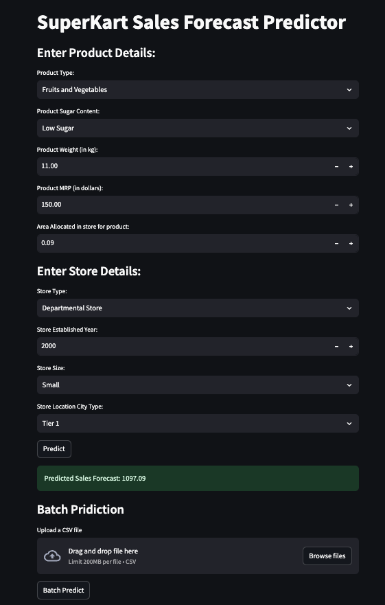

# **Actionable Insights and Business Recommendations**

**Actionable Insights:**

- Model leverages key features like "Product MRP", "Product Weight", "Product Allocated Area", "Store Type", "Store Location City Type" and "Store Established Year" to forecast sales.
- Among above listed, "Product MRP", "Product Weight", "Store Type" and "Product Type" were significant factors influencing the sales.
- While the model provides good overall predictions, variations across different stores still contribute to some prediction error.
- The developed backend API allows both single product/store forecast and batch prediction forecast visa **CSV** upload. This enables API to be scallable and automated.
- Frontend WebApp provides an intuitive user interface for store managers or planners to easily input details and see forecast.

**Business Recommendations:**

- Integrate the API with inventory management to optimize product stock levels and availability accross stores.
- Targeted sales with respect to products, stores and citys based on respective sales forecast.
- Capture additional store level detils and other store information to improve model performance.
- Monitor Models performance using new sales data, compare actual sales vs predict sales.
- Setup alerts for significant deviation from predictions.
- Perform phased rollout and collect feedback on performance and usability both front end and back end.
- Based on user feedback, enhance front end and include any additional factos impacting sales and models performance.